# Chap4

Mijeong Kim

```r
library(tsibble)
library(tsibbledata)
library(tibble)
library(dplyr)
library(knitr)
library(ggplot2)
library(fpp3)
library(fpp2)
library(seasonal)
library(feasts)
```

feasts 패키지는 시계열에서 **FEatures And Statistics**(특징 및 통계)를 계산하는 기능을 포함하고 있다(따라서 이름이 feasts이다).

```r
tourism |>
  features(Trips, list(mean = mean)) |>
  arrange(mean)
```

```
## # A tibble: 304 × 4
##    Region          State              Purpose   mean
##    <chr>           <chr>              <chr>    <dbl>
##  1 Kangaroo Island South Australia    Other    0.340
##  2 MacDonnell      Northern Territory Other    0.449
##  3 Wilderness West Tasmania           Other    0.478
##  4 Barkly          Northern Territory Other    0.632
##  5 Clare Valley    South Australia    Other    0.898
##  6 Barossa         South Australia    Other    1.02
##  7 Kakadu Arnhem   Northern Territory Other    1.04
##  8 Lasseter        Northern Territory Other    1.14
##  9 Wimmera         Victoria           Other    1.15
## 10 MacDonnell      Northern Territory Visiting 1.18
## # ℹ 294 more rows
```

quantile() 함수를 사용하여 최소값, 제1사분위수, 중앙값, 제3사분위수, 최대값을 구할 수 있다.

```r
tourism |> features(Trips, quantile)|>
 arrange(`25%`)
```

```
## # A tibble: 304 × 8
##    Region            State              Purpose   `0%` `25%` `50%` `75%` `100%`
##    <chr>             <chr>              <chr>    <dbl> <dbl> <dbl> <dbl>  <dbl>
##  1 Adelaide Hills    South Australia    Business     0     0 1.26  3.92   28.6
##  2 Adelaide Hills    South Australia    Other        0     0 0.908 2.09    8.95
##  3 Barkly            Northern Territory Other        0     0 0     0.654   7.35
##  4 Barossa           South Australia    Other        0     0 0     1.52   10.4
##  5 Bundaberg         Queensland         Other        0     0 3.86  8.21   31.2
##  6 Central Highlands Victoria           Other        0     0 2.18  4.37   12.6
##  7 Clare Valley      South Australia    Other        0     0 0     1.17    6.82
##  8 East Coast        Tasmania           Other        0     0 0.680 2.12    5.59
##  9 Fraser Coast      Queensland         Other        0     0 1.24  4.42   13.7
## 10 Kakadu Arnhem     Northern Territory Other        0     0 0.126 1.47    8.57
## # ℹ 294 more rows
```

## 4.2 ACF features

Autocorrelation (자기상관)

$$r_k = \frac{\sum_{t=k+1}^{n}(x_t-\bar{x})(x_{t-k}-\bar{x})}
{\sum_{t=1}^{n}(x_t-\bar{x})^2}$$

feat_acf() function

- acf1: 원본 데이터의 첫 번째 자기상관 계수
  $$\text{acf1} = r_1$$
- acf10: 원본 데이터의 첫 10개 자기상관 계수의 제곱합
  $$\text{acf10} = \sum_{k=1}^{10} r_k^2$$
- diff1_acf1: 차분된 데이터의 첫 번째 자기상관 계수

$$y_t = \Delta x_t = x_t - x_{t-1} ~~~\mbox{(1차 차분)}$$
$$r_k^{(\Delta)} = \frac{\sum_{t=k+1}^{n}(y_t-\bar{y})(y_{t-k}-\bar{y})}
{\sum_{t=1}^{n}(y_t-\bar{y})^2}$$
$$\text{diff1_acf1} = r_1^{(\Delta)}$$

- diff1_acf10: 차분된 데이터의 첫 10개 자기상관 계수의 제곱합
  $$\text{diff1_acf10} = \sum_{k=1}^{10} \left(r_k^{(\Delta)}\right)^2$$
- diff2_acf1: 이중 차분된 데이터의 첫 번째 자기상관 계수
  $$z_t = \Delta^2 x_t = x_t - 2x_{t-1} + x_{t-2}~~~\mbox{(2차 차분)}$$
  $$r_k^{(\Delta^2)} = \frac{\sum_{t=k+1}^{n}(z_t-\bar{z})(z_{t-k}-\bar{z})}
  {\sum_{t=1}^{n}(z_t-\bar{z})^2}$$
  $$\text{diff2_acf1} = r_1^{(\Delta^2)}$$
- diff2_acf10: 이중 차분된 데이터의 첫 10개 자기상관 계수의 제곱합
  $$\text{diff2_acf10} = \sum_{k=1}^{10} \left(r_k^{(\Delta^2)}\right)^2$$
- season_acf1: 계절성이 있는 경우, 첫 번째 계절 지연 시점(첫 번째 계절적 래그)의 자기상관 계수

```r
tourism |> features(Trips, feat_acf)
```

```
## # A tibble: 304 × 10
##    Region         State Purpose     acf1 acf10 diff1_acf1 diff1_acf10 diff2_acf1
##    <chr>          <chr> <chr>      <dbl> <dbl>      <dbl>       <dbl>      <dbl>
##  1 Adelaide       Sout… Busine…  0.0333  0.131     -0.520       0.463     -0.676
##  2 Adelaide       Sout… Holiday  0.0456  0.372     -0.343       0.614     -0.487
##  3 Adelaide       Sout… Other    0.517   1.15      -0.409       0.383     -0.675
##  4 Adelaide       Sout… Visiti…  0.0684  0.294     -0.394       0.452     -0.518
##  5 Adelaide Hills Sout… Busine…  0.0709  0.134     -0.580       0.415     -0.750
##  6 Adelaide Hills Sout… Holiday  0.131   0.313     -0.536       0.500     -0.716
##  7 Adelaide Hills Sout… Other    0.261   0.330     -0.253       0.317     -0.457
##  8 Adelaide Hills Sout… Visiti…  0.139   0.117     -0.472       0.239     -0.626
##  9 Alice Springs  Nort… Busine…  0.217   0.367     -0.500       0.381     -0.658
## 10 Alice Springs  Nort… Holiday -0.00660 2.11      -0.153       2.11      -0.274
## # ℹ 294 more rows
## # ℹ 2 more variables: diff2_acf10 <dbl>, season_acf1 <dbl>
```

## 4.3 STL Features

STL 분해(STL decomposition)를 활용하면 추세(trend)와 계절성(seasonality)의 강도를 측정할 수 있다.

### Time series 분해

$$y_t = T_t + S_t + R_t$$

- $T_t$: 추세(trend) 성분
- $S_t$: 계절성(seasonality) 성분
- $R_t$: 잔차(remainder) 성분

$$\text{설명력} = 1 - \frac{\text{설명 못한 부분}}{\text{전체 변동}}$$

### 추세 강도 (Strength of Trend, $F_T$)

추세가 강한 데이터는 계절 조정된 데이터의 변동성이 잔차보다 훨씬 커야 한다. 따라서 추세 강도는 다음과 같이 정의된다:

$$F_T = \max \left( 0, 1 - \frac{\text{Var}(R_t)}{\text{Var}(T_t + R_t)}
\right)$$

값이 0에 가까우면 추세가 거의 없고, 1에 가까우면 강한 추세를 가진다.

### 계절성 강도 (Strength of Seasonality, $F_S$)

계절성 강도는 계절 조정 데이터가 아닌, 추세를 제거한 데이터로 측정되며 다음과 같이 정의된다:

$$F_S = \max \left( 0, 1 - \frac{\text{Var}(R_t)}{\text{Var}(S_t + R_t)}
\right)$$

값이 0에 가까우면 계절성이 거의 없고, 1에 가까우면 강한 계절성을 가진다.

feat_stl() function

```r
tourism |>
  features(Trips, feat_stl)
```

```
## # A tibble: 304 × 12
##    Region State Purpose trend_strength seasonal_strength_year seasonal_peak_year
##    <chr>  <chr> <chr>            <dbl>                  <dbl>              <dbl>
##  1 Adela… Sout… Busine…          0.464                  0.407                  3
##  2 Adela… Sout… Holiday          0.554                  0.619                  1
##  3 Adela… Sout… Other            0.746                  0.202                  2
##  4 Adela… Sout… Visiti…          0.435                  0.452                  1
##  5 Adela… Sout… Busine…          0.464                  0.179                  3
##  6 Adela… Sout… Holiday          0.528                  0.296                  2
##  7 Adela… Sout… Other            0.593                  0.404                  2
##  8 Adela… Sout… Visiti…          0.488                  0.254                  0
##  9 Alice… Nort… Busine…          0.534                  0.251                  0
## 10 Alice… Nort… Holiday          0.381                  0.832                  3
## # ℹ 294 more rows
## # ℹ 6 more variables: seasonal_trough_year <dbl>, spikiness <dbl>,
## #   linearity <dbl>, curvature <dbl>, stl_e_acf1 <dbl>, stl_e_acf10 <dbl>
```

어떤 시계열이 강한 추세를 가지는지, 그리고 어떤 시계열이 가장 계절성이 강한지를 식별할 수 있다.

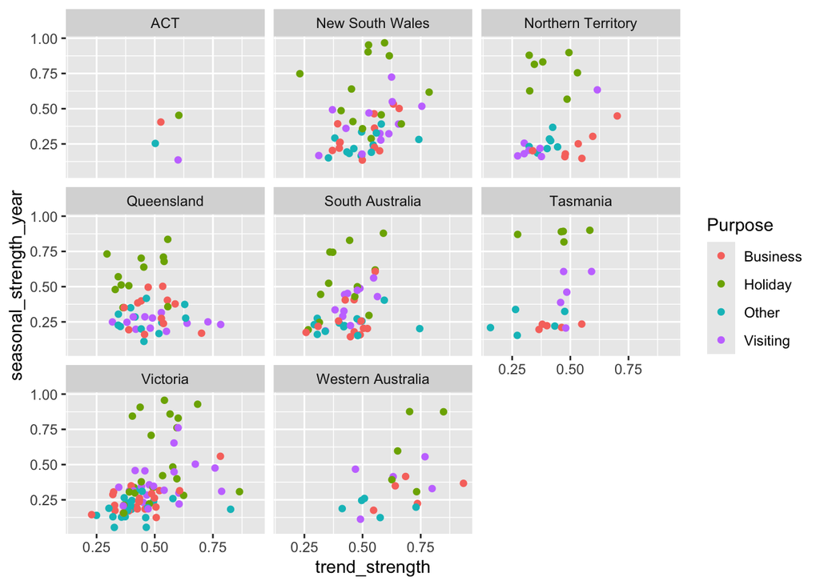

```r
tourism |>
  features(Trips, feat_stl) |>
  ggplot(aes(x = trend_strength, y = seasonal_strength_year,
             col = Purpose)) +
  geom_point() +
  facet_wrap(vars(State))
```

휴일 시계열은 계절성이 가장 강하며, 서호주와 빅토리아에서 뚜렷한 추세가 나타난다.

```r
tourism |>
  features(Trips, feat_stl) |>
  filter(seasonal_strength_year == max(seasonal_strength_year))
```

```
## # A tibble: 1 × 12
##   Region  State Purpose trend_strength seasonal_strength_year seasonal_peak_year
##   <chr>   <chr> <chr>            <dbl>                  <dbl>              <dbl>
## 1 Snowy … New … Holiday          0.595                  0.967                  3
## # ℹ 6 more variables: seasonal_trough_year <dbl>, spikiness <dbl>,
## #   linearity <dbl>, curvature <dbl>, stl_e_acf1 <dbl>, stl_e_acf10 <dbl>
```

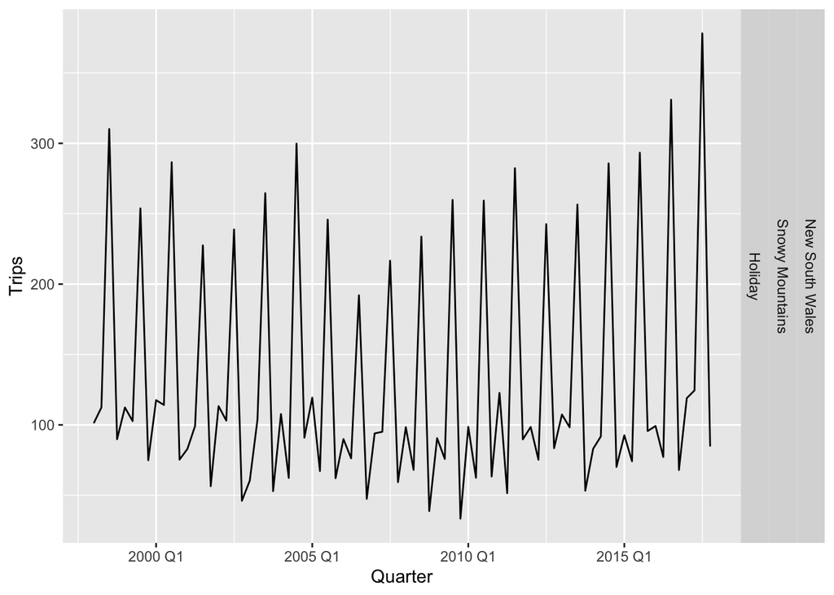

```r
tourism |>
  features(Trips, feat_stl) |>
  filter(
    seasonal_strength_year == max(seasonal_strength_year)
  ) |>
  left_join(tourism, by = c("State", "Region", "Purpose"), multiple = "all") |>
  ggplot(aes(x = Quarter, y = Trips)) +
  geom_line() +
  facet_grid(vars(State, Region, Purpose))
```

### 추가적인 STL 기반 특징

`feat_stl()` 함수는 추가적인 특징들도 반환한다:

- **`seasonal_peak_year`**: 계절성 성분이 가장 높은 시점(월 또는 분기)을 나타내며, 시즌의 특성을 보여준다. 예를 들어, 호주 관광 데이터에서 3분기에 피크가 있다면 겨울철 여행이 많고, 1분기에 피크가 있다면 여름철이 인기 있는 시기임을 의미한다.
- **`seasonal_trough_year`**: 계절성 성분이 가장 낮은 시점(월 또는 분기)을 나타낸다.
- **`spikiness`**: STL 분해의 잔차( $R_t$ )에서 급격한 변동(스파이크)이 얼마나 자주 발생하는지를 측정한다. 이는 잔차의 leave-one-out 분산의 분산으로 계산된다.
- **`linearity`**: 추세 성분의 선형성을 측정하며, 추세 성분에 선형 회귀를 적용했을 때의 회귀 계수로 계산된다.
- **`curvature`**: 추세 성분의 곡률을 측정하며, 직교 이차 회귀(orthogonal quadratic regression)의 계수를 기반으로 계산된다.
- **`stl_e_acf1`**: STL 분해 잔차 시리즈의 첫 번째 자기상관 계수.
- **`stl_e_acf10`**: STL 분해 잔차 시리즈의 첫 10개 자기상관 계수의 제곱합.

이러한 특징을 활용하면, 강한 계절성을 가지는 지역이나 추세가 뚜렷한 지역을 식별할 수 있다.

## 4.4 Other features

feasts 패키지는 시계열 분석에 유용한 몇 가지 특징(features)을 계산하는 기능을 제공하며, 추가적인 사용자 정의 특징도 쉽게 추가할 수 있다.

### Hurst 계수 계산

- `coef_hurst`: 시계열의 Hurst 계수를 계산하여 장기 메모리 여부를 측정한다. 높은 값은 장기 메모리를 의미한다.

### 스펙트럼 엔트로피 계산

- `feat_spectral`: Shannon 스펙트럼 엔트로피를 계산하여 시계열의 예측 가능성을 측정한다. 값이 0에 가까우면 예측이 쉽고, 1에 가까우면 예측이 어렵다.

### 백색잡음(white noise) 여부 테스트

- `box_pierce`: Box-Pierce 검정을 수행하여 백색잡음 여부를 확인한다.
- `ljung_box`: Ljung-Box 검정을 수행하여 백색잡음 여부를 확인한다.

### 부분 자기상관(partial autocorrelation)

- `feat_pacf`: 부분 자기상관을 계산하며, 첫 5개의 부분 자기상관 제곱합, 차분 후 부분 자기상관 등을 포함한다.

### 정상성(stationarity) 검정

- `unitroot_kpss`: KPSS 검정을 수행하여 시계열의 정상성 여부를 판별한다.
- `unitroot_pp`: Phillips-Perron 검정을 수행하여 비정상성 여부를 판별한다.
- `unitroot_ndiffs`: KPSS 검정을 기반으로 정상성을 달성하기 위해 필요한 차분 횟수를 계산한다.
- `unitroot_nsdiffs`: 계절 차분을 통해 정상성을 달성하기 위한 차분 횟수를 계산한다.

### 변동성 관련 특징

- `var_tiled_mean`: 블록 평균(일정 구간별 평균)의 분산을 계산하여 시계열의 안정성을 평가한다.
- `var_tiled_var`: 블록 분산(일정 구간별 분산)의 변화를 계산하여 시계열의 “덩어리짐(lumpiness)”을 평가한다.

### 시계열 변동 탐지

- `shift_level_max`: 구간별 평균 이동의 최대 변화를 찾는다.
- `shift_level_index`: 평균 이동이 가장 큰 지점을 찾는다.
- `shift_var_max`: 구간별 분산 이동의 최대 변화를 찾는다.
- `shift_var_index`: 분산 이동이 가장 큰 지점을 찾는다.
- `shift_kl_max`: KL 발산을 기반으로 분포 변화가 가장 큰 지점을 찾는다.
- `shift_kl_index`: KL 발산이 가장 큰 변동 지점을 찾는다.

### 기타 특징

- `n_crossing_points`: 시계열이 중앙값을 넘는 횟수를 계산한다.
- `longest_flat_spot`: 시계열에서 변동이 거의 없는 가장 긴 구간의 길이를 계산한다.
- `stat_arch_lm`: ARCH(자기회귀 조건부 이분산) 효과 검정을 수행한다.
- `guerrero`: Guerrero 방법을 사용하여 Box-Cox 변환의 최적 λ 값을 계산한다.

## 4.5 Exploring Australian tourism data

```r
tourism_features <- tourism |>
  features(Trips, feature_set(pkgs = "feasts"))
tourism_features
```

```
## # A tibble: 304 × 51
##    Region State Purpose trend_strength seasonal_strength_year seasonal_peak_year
##    <chr>  <chr> <chr>            <dbl>                  <dbl>              <dbl>
##  1 Adela… Sout… Busine…          0.464                  0.407                  3
##  2 Adela… Sout… Holiday          0.554                  0.619                  1
##  3 Adela… Sout… Other            0.746                  0.202                  2
##  4 Adela… Sout… Visiti…          0.435                  0.452                  1
##  5 Adela… Sout… Busine…          0.464                  0.179                  3
##  6 Adela… Sout… Holiday          0.528                  0.296                  2
##  7 Adela… Sout… Other            0.593                  0.404                  2
##  8 Adela… Sout… Visiti…          0.488                  0.254                  0
##  9 Alice… Nort… Busine…          0.534                  0.251                  0
## 10 Alice… Nort… Holiday          0.381                  0.832                  3
## # ℹ 294 more rows
## # ℹ 45 more variables: seasonal_trough_year <dbl>, spikiness <dbl>,
## #   linearity <dbl>, curvature <dbl>, stl_e_acf1 <dbl>, stl_e_acf10 <dbl>,
## #   acf1 <dbl>, acf10 <dbl>, diff1_acf1 <dbl>, diff1_acf10 <dbl>,
## #   diff2_acf1 <dbl>, diff2_acf10 <dbl>, season_acf1 <dbl>, pacf5 <dbl>,
## #   diff1_pacf5 <dbl>, diff2_pacf5 <dbl>, season_pacf <dbl>,
## #   zero_run_mean <dbl>, nonzero_squared_cv <dbl>, zero_start_prop <dbl>, …
```

urca 및 fracdiff 패키지가 설치되어 있으면, 주요 변수인 Region, State, Purpose의 모든 조합에 대해 48개의 특징을 추출할 수 있다.

이전에는 한 특징을 다른 특징과 비교하여 그래프로 나타내는 방법을 살펴보았으며(4.3절), 여러 특징을 쌍(pairwise)으로 비교하는 플롯도 가능하다. 예를 들어, Figure 4.3에서는 계절성과 관련된 모든 특징과 Purpose 변수를 함께 시각화한 결과를 보여준다.

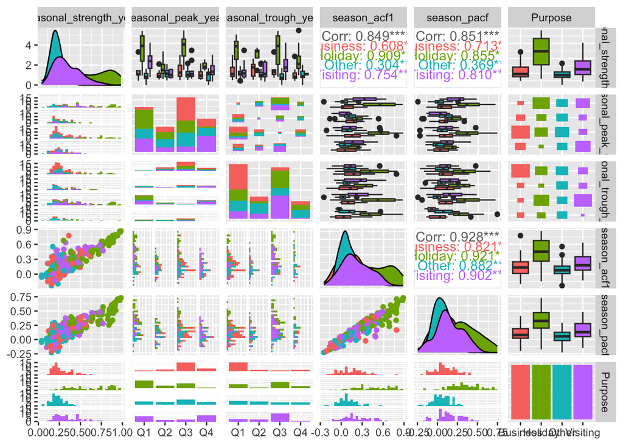

```r
library(glue)
tourism_features |>
  select_at(vars(contains("season"), Purpose)) |>
  mutate(
    seasonal_peak_year = seasonal_peak_year +
      4*(seasonal_peak_year==0),
    seasonal_trough_year = seasonal_trough_year +
      4*(seasonal_trough_year==0),
    seasonal_peak_year = glue("Q{seasonal_peak_year}"),
    seasonal_trough_year = glue("Q{seasonal_trough_year}"),
  ) |>
  GGally::ggpairs(mapping = aes(colour = Purpose))
```

이 그래프에서 Purpose 변수는 색상으로 매핑된 것이다.

- 세 가지 계절성 관련 수치(seasonal_strength_year, season_acf1, season_pacf)는 양의 상관관계를 가진다.
- 좌하단 및 우상단 패널에서, 가장 강한 계절성을 가진 시계열은 휴일과 관련이 있다. 하단 행의 막대 그래프를 보면, Business 여행의 계절적 피크는 3분기에 가장 많고, 1분기에 가장 적다.
- 여러 변수를 동시에 탐색하는 것은 어렵기 때문에, **주성분 분석(PCA)**과 같은 차원 축소 기법을 사용하면 데이터의 주요 변동을 설명하는 선형 조합을 얻을 수 있다.

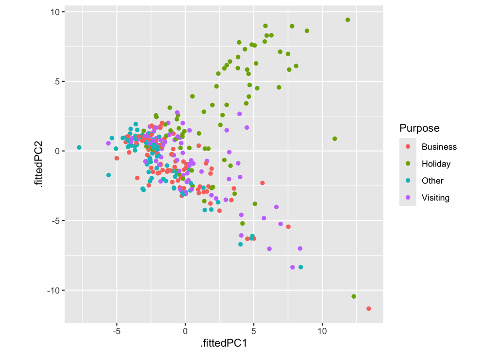

```r
library(broom)
pcs <- tourism_features |>
  select(-State, -Region, -Purpose) |>
  prcomp(scale = TRUE) |>
  augment(tourism_features)
pcs |>
  ggplot(aes(x = .fittedPC1, y = .fittedPC2, col = Purpose)) +
  geom_point() +
  theme(aspect.ratio = 1)
```

- Figure 4.4의 각 점은 하나의 시계열를 나타내며, 48개의 특징을 기반으로 플롯에서 위치가 결정된다. 첫 번째 주성분(.fittedPC1)은 데이터의 변동성을 가장 많이 설명하는 특징들의 선형 결합이며, 두 번째 주성분(.fittedPC2)은 첫 번째 주성분과 상관관계가 없으면서 다음으로 많은 변동성을 설명하는 특징들의 선형 결합이다.
- 휴일 관련 시계열은 다른 시계열과 상당히 다르게 나타난다. 대부분의 휴일 관련 시계열은 플롯의 상단에 위치하고, 나머지 시계열은 대부분 하단에 위치한다. 즉, 두 번째 주성분이 휴일 여행과 기타 여행 유형을 구별하는 역할을 하고 있음을 보여준다.
- 또한, 해당 플롯을 통해 특성이 이례적인 시계열을 식별할 수 있다. 대부분의 시계열과 거리가 떨어져 있는 점들이 이러한 이상 시계열에 해당하며, 네 개의 시계열이 특히 두드러지게 나타난다.

```r
outliers <- pcs |>
  filter(.fittedPC1 > 10) |>
  select(Region, State, Purpose, .fittedPC1, .fittedPC2)
outliers
```

```
## # A tibble: 4 × 5
##   Region                 State             Purpose  .fittedPC1 .fittedPC2
##   <chr>                  <chr>             <chr>         <dbl>      <dbl>
## 1 Australia's North West Western Australia Business       13.4    -11.3
## 2 Australia's South West Western Australia Holiday        10.9      0.880
## 3 Melbourne              Victoria          Holiday        12.3    -10.4
## 4 South Coast            New South Wales   Holiday        11.9      9.42
```

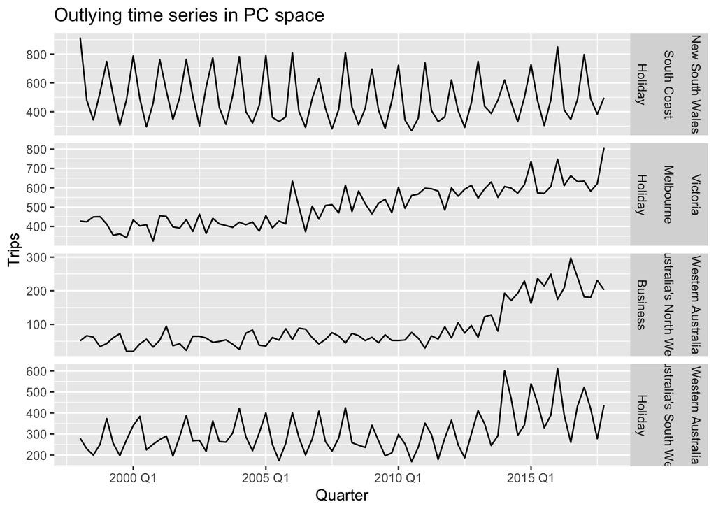

```r
outliers |>
  left_join(tourism, by = c("State", "Region", "Purpose"), multiple = "all") |>
  mutate(Series = glue("{State}", "{Region}", "{Purpose}", .sep = "\n\n")) |>
  ggplot(aes(x = Quarter, y = Trips)) +
  geom_line() +
  facet_grid(Series ~ ., scales = "free") +
  labs(title = "Outlying time series in PC space")
```

- NSW 남부 해안의 휴가 방문은 계절성이 강하지만 추세가 거의 없으며, 대부분의 호주 휴양지는 시간이 지남에 따라 추세를 보인다.
- 멜버른은 대부분의 호주 휴양지가 강한 계절성을 가지는 것과 달리, 거의 계절성이 없는 독특한 휴양지이다.
- 서호주 북서부는 최근 몇 년간 비즈니스 관광이 증가했지만, 계절성이 거의 없는 것이 특징이다.
- 서호주 남서부는 최근 몇 년간 휴가 관광이 증가하면서 동시에 강한 계절성을 보이는 점에서 독특하다.